# Stated Preferences

Author

Natalie Smith

# 1 Background:

Climate change is leading to more unpredictable weather patterns, such as variable rainfall, droughts, and floods, which can negatively impact agriculture and fisheries. One way to mitigate these risks is through insurance, like “index insurance” for farmers. In this system, farmers pay an annual premium, and the insurance uses a reliable, measurable index (such as rainfall) to determine payouts. If rainfall falls below a certain threshold, the farmer receives a financial payout to compensate for low income due to poor agricultural conditions.

The Environmental Markets Lab (emLab) at Bren conducted a study to evaluate fishermen’s willingness to pay for index insurance in fisheries. In the study, fishermen were presented with a randomized insurance premium and asked whether they would pay it. Responses were either “yes” (willing to pay) or “no” (unwilling to pay). Along with their responses, socioeconomic data and risk-aversion metrics were collected to understand what influences their willingness to pay for such insurance.

# 2 Data

```r
# Load libraries
library(tidyverse)
library(here)
library(kableExtra)
library(knitr)

# Load the data
insurance_df <- read_csv(here("data", "insurance.csv"))
```

The columns in the data set are as follows:

- ID = Respondent identifier
- Premium = the (randomized) premium offered to that respondent
- Yes = whether the respondent answered Yes (1) or No (0)
- Age = age of the respondent
- Years = number of years the respondent has been fishing
- Length = the length of the respondent’s fishing vessel (in meters)
- Risk = a measure of risk aversion (higher than 1 indicates risk-averse, lower than 1 indicates risk-loving)

# 3 Regression Analysis:

## 3.1

1. *Load the dataset into R and make a summary table describing the min, mean, and max of each variable.*

```r
summary(insurance_df)
```

```
       ID              Yes          Premium          Age           Years
 Min.   :  1.00   Min.   :0.00   Min.   :   0   Min.   :22.0   Min.   : 1.00
 1st Qu.: 25.75   1st Qu.:0.00   1st Qu.: 300   1st Qu.:44.0   1st Qu.:11.00
 Median : 50.50   Median :1.00   Median : 500   Median :50.0   Median :15.00
 Mean   : 50.50   Mean   :0.52   Mean   : 512   Mean   :49.9   Mean   :14.43
 3rd Qu.: 75.25   3rd Qu.:1.00   3rd Qu.: 700   3rd Qu.:56.0   3rd Qu.:18.00
 Max.   :100.00   Max.   :1.00   Max.   :1000   Max.   :69.0   Max.   :26.00
     Length           Risk
 Min.   :10.00   Min.   :0.740
 1st Qu.:18.75   1st Qu.:1.147
 Median :26.00   Median :1.325
 Mean   :25.43   Mean   :1.359
 3rd Qu.:32.25   3rd Qu.:1.525
 Max.   :40.00   Max.   :2.210
```

## 3.2

$$Yes_{i} = a_{0} + a_{1}*Premium_{i} + a_{2}*Age_{i} + a_{3}*Years_{i} + a_{4}*Length_{i} + a_{5}*Risk_{i} + e_{i}$$
2. *Run the regression described above. Make a summary table of the coefficient estimates and the p-values for each of them.*

```r
# Run linear regression on variables in formula
lm_insurance <- lm(Yes ~ Premium + Age + Years + Length + Risk, data = insurance_df)

# Extract the coefficients summary
coeff_summary <- summary(lm_insurance)$coefficients
# summary(lm_insurance)

# Display the coefficients with kable
kable(coeff_summary, caption = "Summary of Estimated Coefficients and P-values") %>%
  kable_styling(bootstrap_options =
                  c("striped", "hover", "condensed", "responsive"))
```

Summary of Estimated Coefficients and P-values

|  | Estimate | Std. Error | t value | Pr(>\|t\|) |
| --- | --- | --- | --- | --- |
| (Intercept) | 0.3896223 | 0.2772293 | 1.4054152 | 0.1631944 |
| Premium | -0.0017888 | 0.0001447 | -12.3660502 | 0.0000000 |
| Age | 0.0035704 | 0.0041888 | 0.8523648 | 0.3961782 |
| Years | 0.0062549 | 0.0068246 | 0.9165295 | 0.3617347 |
| Length | 0.0176010 | 0.0036200 | 4.8621246 | 0.0000046 |
| Risk | 0.2429055 | 0.1034231 | 2.3486588 | 0.0209360 |

## 3.3

3. *Write a 1-2 sentence interpretation of the coefficient estimate for a1.*

The coefficient for **Premium** is -0.0017888, meaning that for each one-unit increase in the premium, the probability of purchasing insurance decreases by about 0.0018. The very low p-value (< 2e-16) indicates this result is statistically significant, showing that higher costs reduce the likelihood of purchase.

## 3.4

4. *Do the coefficient estimates have the sign you would have expected?*

**Premium:** The coefficient is negative and significant, which matches expectations. As the premium increases, the probability of purchasing the insurance decreases, which is logical since higher costs typically deter buyers.

**Age:** The coefficient is positive (0.0035704) but not statistically significant (p-value = 0.3962), meaning age does not have a significant effect on the likelihood of purchasing insurance in this model. I expected this to go either way, as older fishermen might be more risk-averse and willing to pay for insurance, or they might be more financially limited.

**Years:** The coefficient for years of experience is positive (0.0063) but not statistically significant (p = 0.3617), suggesting it doesn’t strongly influence willingness to pay for insurance. This aligns with expectations, as more experience may lead to better risk understanding and increased willingness to pay.

**Length:** The positive coefficient (0.0176) and statistically significant p-value (4.65e−06) indicate that larger vessel owners are more likely to buy insurance. This is expected, as larger vessels often signify more assets and higher risk, making insurance more necessary.

**Risk:** The coefficient for risk aversion is positive (0.2429055) and statistically significant (p-value = 0.0209). This suggests that more risk-averse fishermen are more likely to buy insurance, which aligns with expectations as those who are more risk-averse tend to seek security.

## 3.5

5. *Consider a fisher named Susan, who is 35 years old, has been fishing for 8 years, uses a 10m boat, and has a risk score of 1.1. Make a plot with the Premium on the x-axis and the Probability of Susan’s purchase on the y-axis. What is Susan’s average willingness to pay for index insurance?*

$$Intercept_{susan} = a_{0} + a_{2}*35 + a_{3}*8 + a_{4}*10 + a_{5}*1.1$$

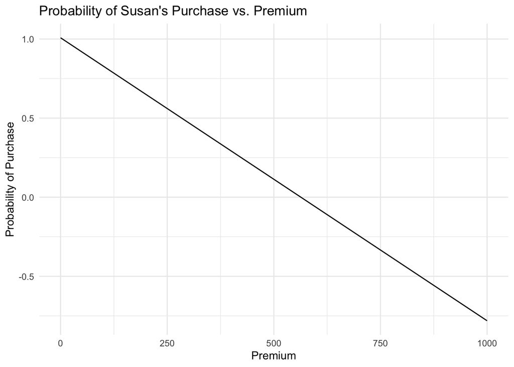

Figure 1: Illustrates Susan’s predicted probability of purchasing index insurance as a function of varying premiums, based on a linear regression model from a study of fishermen.

```r
# Create a data frame for Susan with premiums ranging from the min to max values in the insurance data
susan_df <- data.frame(
  Premium = seq(min(insurance_df$Premium), max(insurance_df$Premium), length.out = 100),
  Age = 35,
  Years = 8,
  Length = 10,
  Risk = 1.1
)

# Calculate the predicted probabilities for Susan based on her profile
susan_df$yes_prob <- predict(lm_insurance, newdata = susan_df, type = "response")

# Plot Premium vs. Probability of Purchase
ggplot(susan_df, aes(x = Premium, y = yes_prob)) +
  geom_line() +
  labs(title = "Probability of Susan's Purchase vs. Premium",
       x = "Premium",
       y = "Probability of Purchase") +
  theme_minimal()
```

```r
# Calculate the average willingness to pay by finding the area under the curve (area of a triangle)

# Intercept (represents the height of the triangle)
intercept <- coef(lm_insurance)["(Intercept)"] +
             35 * coef(lm_insurance)["Age"] +
             8 * coef(lm_insurance)["Years"] +
             10 * coef(lm_insurance)["Length"] +
             1.1 * coef(lm_insurance)["Risk"]

# Slope
slope <- coef(lm_insurance)["Premium"]

# Represents the base of the triangle (where the slope hits 0)
base_premium <- intercept / abs(slope)

# Calculate the area of the triangle
wtp <- 0.5 * base_premium * 1

# Here come the results!
# wtp
```

Susan’s average willingness to pay for index insurance is approximately **$281.71**